# Capstone 1 percent sample exploration

Vijay Goel

July 18, 2015

#### Synopsis

This project is about Text mining data from blogs, news and twitter, to predict next word as a user types. This document covers first part, which shares results from initial exploration of data, and plan for future prediction and presentation. This document has specified tasks, assumptions and approach, summary statistics from data cleaning, interesting results from early explorations. Please let me know of any feedback! Happy to incorporate.

##### Tasks to accomplish

Tokenization and Filtering - Data manually downloaded from links provided in course assignment and unzipped. US language selelcted, and functions created for tokenization and filtering. Logic shared below, followed by results. Scripts are loaded at https://github.com/goelvijayk/capstone/blob/master/scratch_capstone.R

##### Logic used

Capital/Lower case: All converted to lower case, and value of capitalization was ignored, towards prediction of next word. It is assumed that abbreviations, formatting (e.g. of first word in sentence) are of very low importance.

Punctuation: handled by standard tm_map filters. All punctuation was removed. This spoils cases like I’d, wasn’t, phrases within quotation marks etc. Impact assumed to be small.

Times, dates, numbers and currency: Assumed not useful for prediction. All were removed.

Typos: not addressed. Can try stemming, and recombining the words later. Or try connecting to an existing dictionary. Skipped for now.

Garbage/wrong language: Assumed to have non-alphabets, non-numbers. Any element with any character outside of English was treated as foreign, and was removed from raw data.

Special characters: e.g. -, ., !, @ etc. were manually listed and removed. These are fairly hard to predict, and they mix the words up. Ignored for now.

#### Results

```
##          [,1]
## messages "Few interesting facts -"
##          "Total lines in en_US.blogs.txt are -  899288"
##          "Total lines in en_US.news.txt are -  1010242"
##          "Total lines in en_US.twitter.txt are -  2360148"
##          "Length of longest line in en_US.blogs.txt is -  40833"
##          "Length of longest line in en_US.news.txt is -  11384"
##          "Length of longest line in en_US.twitter.txt is -  140"
##          "Total words in en_US.twitter.txt sample are -  235968"
##          "Total unique words in en_US.twitter.txt sample are -  45049"
##          "Total words in en_US.blogs.txt sample are -  301667"
##          "Total unique words in en_US.blogs.txt sample are -  49919"
##          "Total words in en_US.news.txt sample are -  283213"
##          "Total unique words in en_US.news.txt sample are -  50780"
##          "Total unique words -  108120"
##          "Unique words removed by changing to lower case -  0"
##          "Unique words removed due to symbols -  40261"
##          "Unique words removed due to profanity -  0"
##          "Unique words removed by removing punctuation -  6934"
##          "Unique words removed by removing numbers -  3498"
##          "Unique stopwords removed -  137"
##          "Unique words removed due to special character entries -  0"
```

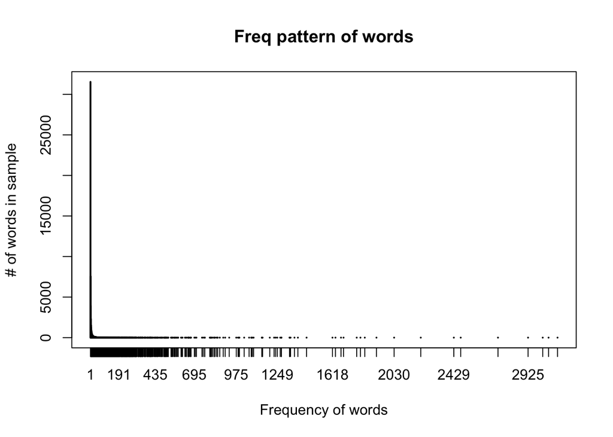

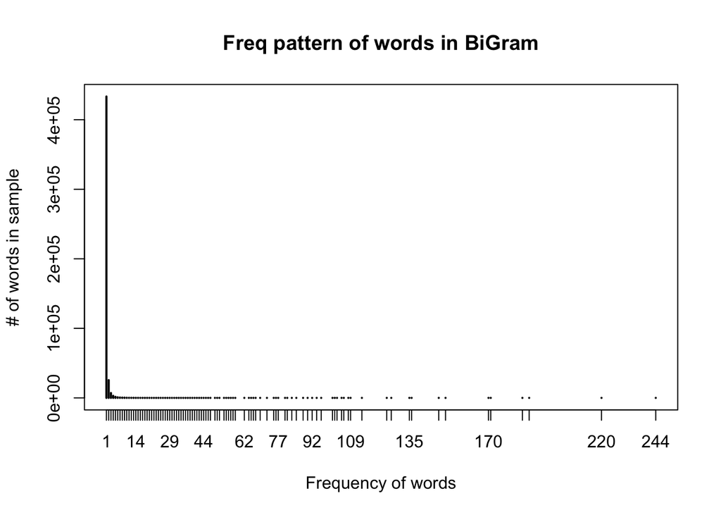

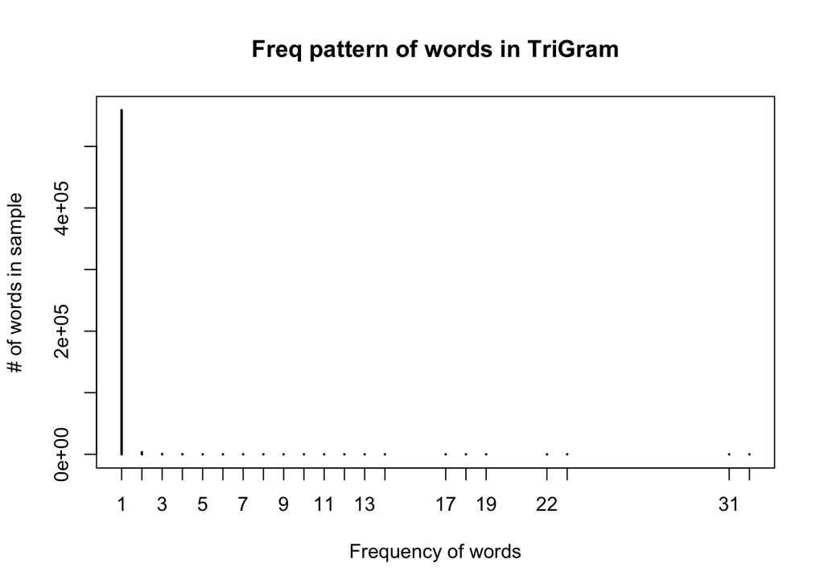

```
## [1] "Top words and phrases - "
```

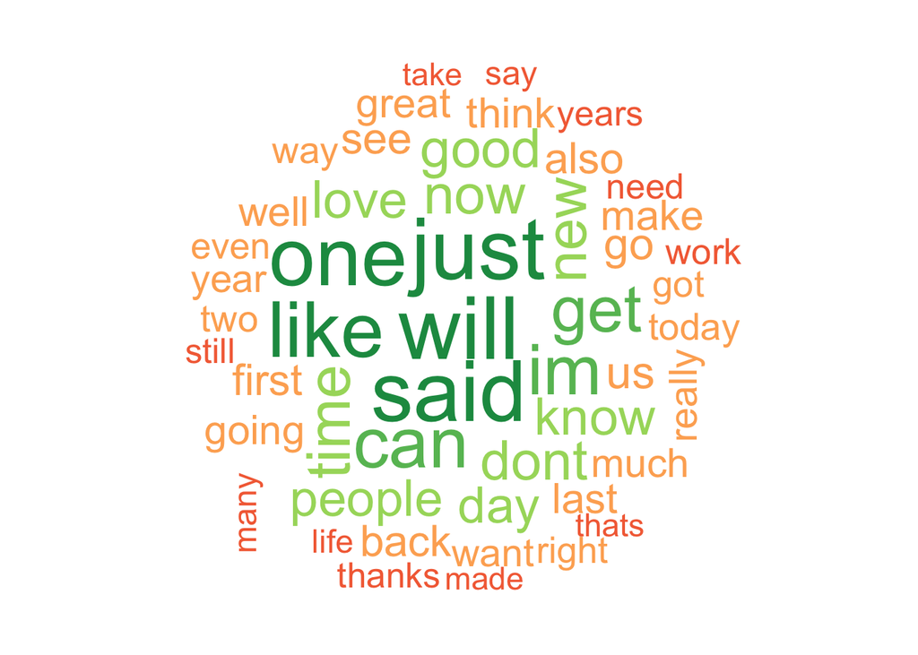

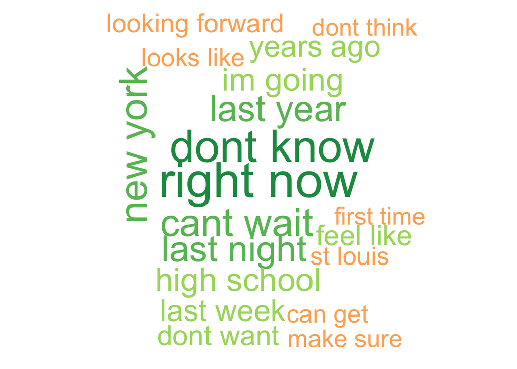

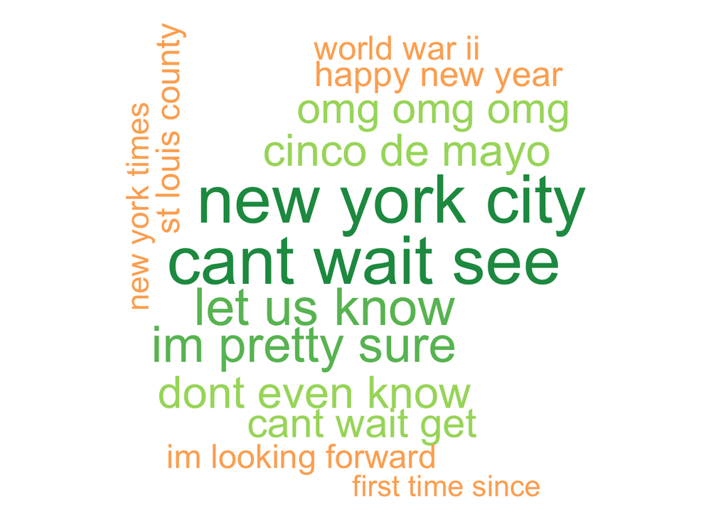

Future plan: Attempt will mainly be to create a shiny app that can help predict next word as user types on a PC. This document only provides a confirmation that basic functions are documents are working.